# Dupilumab Analaysis

Project: Prescribing Patterns of Dupilumab for Atopic Dermatitis Analyst: Grace Bosma, Camille Hochheimer Investigators: Torunn Sivesind, Robert P. Dellavalle, Lisa Schilling Report Generated: June 07, 2022

[figure not shown]

# 1 Project Summary

Eligibility of those included is displayed below.

[interactive chart not shown]

# 2 Summary Statistics

## 2.1 Overall By Medication

This table displays the overall summary statistics in three columns: “Did not receive”, “Received Dupilumab”, and “Overall”. These column variables can be interpreted as if an indiviudal included was *ever* prescribed Dupilumab. Those prescribed with a diagnosis of Besnier’s Prurigo were combined with those recieving an diagnosis of Atopic Dermatitis.

| User Prevalence | Did not Receive (N=6172) | Received Dupilumab (N=249) | Overall (N=6421) |
| --- | --- | --- | --- |
| Age |  |  |  |
| Mean (SD) | 53.3 (17.9) | 51.4 (16.7) | 53.2 (17.9) |
| Median [Min, Max] | 54.0 [22.0, 89.0] | 52.0 [22.0, 87.0] | 54.0 [22.0, 89.0] |
| Sex |  |  |  |
| Female | 3532 (57.2%) | 146 (58.6%) | 3678 (57.3%) |
| Male | 2621 (42.5%) | 102 (41.0%) | 2723 (42.4%) |
| Missing | 19 (0.3%) | 1 (0.4%) | 20 (0.3%) |
| Race |  |  |  |
| American Indian and Alaska Native | 20 (0.3%) | 1 (0.4%) | 21 (0.3%) |
| Asian | 246 (4.0%) | 11 (4.4%) | 257 (4.0%) |
| Black or African American | 397 (6.4%) | 34 (13.7%) | 431 (6.7%) |
| Multiple Race | 161 (2.6%) | 6 (2.4%) | 167 (2.6%) |
| Native Hawaiian and Other Pacific Islander | 12 (0.2%) | 0 (0%) | 12 (0.2%) |
| Other | 340 (5.5%) | 13 (5.2%) | 353 (5.5%) |
| White or Caucasian | 4912 (79.6%) | 179 (71.9%) | 5091 (79.3%) |
| Missing | 84 (1.4%) | 5 (2.0%) | 89 (1.4%) |
| Ethnicity |  |  |  |
| Hispanic | 563 (9.1%) | 20 (8.0%) | 583 (9.1%) |
| Non-Hispanic | 5491 (89.0%) | 226 (90.8%) | 5717 (89.0%) |
| Missing | 118 (1.9%) | 3 (1.2%) | 121 (1.9%) |
| Diagnosis |  |  |  |
| Atopic dermatitis | 3050 (49.4%) | 213 (85.5%) | 3263 (50.8%) |
| Atopic neurodermatitis | 107 (1.7%) | 14 (5.6%) | 121 (1.9%) |
| Flexural eczema | 758 (12.3%) | 5 (2.0%) | 763 (11.9%) |
| Nummular eczema | 1120 (18.1%) | 6 (2.4%) | 1126 (17.5%) |
| Vesicular eczema | 1137 (18.4%) | 11 (4.4%) | 1148 (17.9%) |

## 2.2 Multiple Prescriptions

There were no individuals that received only one prescription of Dupilumab. Each individual included had either multiple prescriptions, refills or quantities of dupilumab.

# 3 Test Results

## 3.1 Overall

We assessed whether the proportion of patients who received Dupilumab was diffferent based on patient characteristics. Each patient characteristic in the table below was assessed using logistic regression with the binary outcome of receiving Dupilumab or not. The p-values associated with multi-level categorical characteristics (race, diagnoses) were corrected for multiple testing using the False Discovery Rate method (Benjamini-Hochberg correction). Reference levels include white race, non-Hispanic ethnicity, female sex, and Atopic Dermatitis as first eligible diagnosis.

[output not shown]

* Patients identifying as American Indian, Alaska Native, Native Hawaiian or Other Pacific Islander race resulted in trivial estimates due to low prevelence within our data.

# 4 Visualizations

## 4.1 Dupilumab Prescription Count

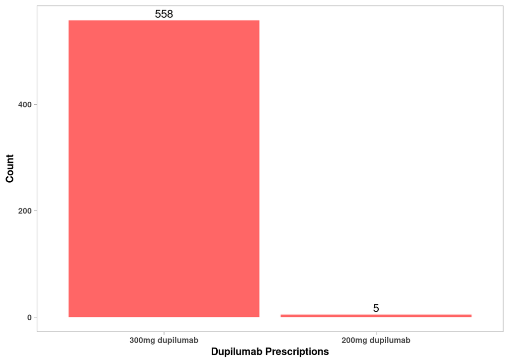

## 4.2 Atopic Dermatitis (AD) Count

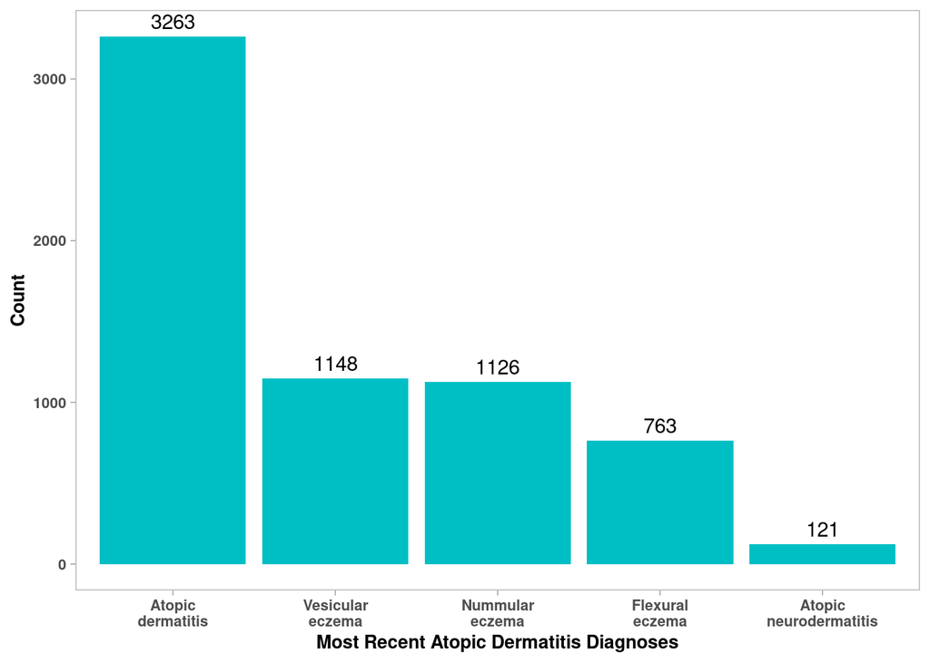

## 4.3 Atopic Dermatitis x Dupilumab Presriptions

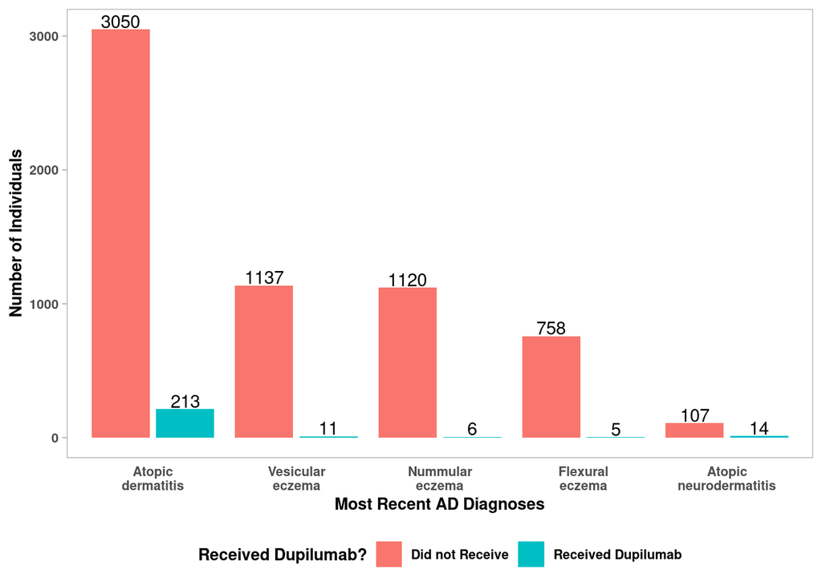

[figure not shown]